# Pre-processing ASVs with phyloseq

Daphne Garcia

2025-03-30

The goal of this file is to combine `asv_table`, `tax_table`, and metadata and create phyloseq object. Then, remove any potential contaminants and evaluate the accuracy of the sequencing run, to consolidate into a `raw_preprocessed_physeq` phyloseq data object.

## Specific Steps:

1. Combine `asv_table`, `tax_table`, and metadata into a phyloseq object.
2. Remove any contaminating ASVs (chloroplasts, mitochondria, negative controls)
3. Evaluate the mock community/positive control if they exist
4. Check for reverse complements
5. Remove samples with low sequencing depth

## Output

1. pre-processed S4 phyloseq object: `raw_preprocessed_physeq.RData`.

## Load Packages, timing,

```r
#install.packages("BiocManager")
#BiocManager::install("Biostrings")


# Load packages with pacman
# Be sure that you load dada2 & Patchwork, which we didn't do in class on March 12th
pacman::p_load(devtools, phyloseq, dada2, patchwork, Biostrings, tidyverse,
               # Note to add ggpubr & rstatix!!
               ggpubr, rstatix, install = FALSE)

# What time did we start running this script?
start_time <- Sys.time()
```

## 1. Load Data

### 1a. Metadata

Load the metadata

```r
# load in metadata
metadata_df <-
  read_csv("data/metadata.csv") %>%
  # Fix Column Name
  dplyr::rename("sample_names" = "Run") %>%
  # Add sample names also as a column
  mutate(names = sample_names)
# Inspect
head(metadata_df)
```

```
## # A tibble: 6 × 34
##   sample_names `Assay Type` AvgSpotLen    Bases BioProject  BioSample
##   <chr>        <chr>             <dbl>    <dbl> <chr>       <chr>
## 1 SRR19509095  AMPLICON            500 54925500 PRJNA843708 SAMN28766924
## 2 SRR19509096  AMPLICON            500 50099000 PRJNA843708 SAMN28766923
## 3 SRR19509097  AMPLICON            500 55474000 PRJNA843708 SAMN28766922
## 4 SRR19509098  AMPLICON            500 55287500 PRJNA843708 SAMN28766921
## 5 SRR19509099  AMPLICON            500 57233000 PRJNA843708 SAMN28766974
## 6 SRR19509100  AMPLICON            500 54169000 PRJNA843708 SAMN28766973
## # ℹ 28 more variables: BioSampleModel <chr>, Bytes <dbl>, `Center Name` <chr>,
## #   Collection_Date <chr>, Consent <chr>, `DATASTORE filetype` <chr>,
## #   `DATASTORE provider` <chr>, `DATASTORE region` <chr>, Experiment <chr>,
## #   geo_loc_name_country <chr>, geo_loc_name_country_continent <chr>,
## #   geo_loc_name <chr>, Host <chr>, Instrument <chr>, isolation_source <chr>,
## #   lat_lon <chr>, `Library Name` <chr>, LibraryLayout <chr>,
## #   LibrarySelection <chr>, LibrarySource <chr>, Organism <chr>, …
```

```r
dim(metadata_df)
```

```
## [1] 60 34
```

```r
# include dada2 output
load("data/data_filtered/track_read_counts.RData")

# Take a look
glimpse(track_counts_df)
```

```
## Rows: 60
## Columns: 6
## $ sample_names <chr> "SRR19509095_R1_filtered.fastq.gz", "SRR19509096_R1_filte…
## $ denoisedF    <dbl> 94686, 86700, 96278, 95458, 102411, 96536, 105011, 96288,…
## $ denoisedR    <dbl> 94497, 86185, 96091, 95003, 102405, 96742, 104681, 95804,…
## $ merged       <dbl> 87854, 81615, 91155, 88314, 89705, 87311, 95255, 84865, 9…
## $ nochim       <dbl> 67016, 51886, 63907, 58152, 53191, 62810, 74893, 52689, 7…
## $ num_ASVs     <dbl> 419, 348, 372, 471, 661, 618, 629, 638, 455, 381, 720, 38…
```

```r
dim(track_counts_df)
```

```
## [1] 60  6
```

```r
# Check filenames
head(track_counts_df$sample_names)
```

```
## [1] "SRR19509095_R1_filtered.fastq.gz" "SRR19509096_R1_filtered.fastq.gz"
## [3] "SRR19509097_R1_filtered.fastq.gz" "SRR19509098_R1_filtered.fastq.gz"
## [5] "SRR19509099_R1_filtered.fastq.gz" "SRR19509100_R1_filtered.fastq.gz"
```

```r
# Fix sample names in track_reads
track_counts_df$sample_names <- sapply(strsplit(track_counts_df$sample_names, "_"), `[`, 1)

# Intuition check
head(track_counts_df$sample_names)
```

```
## [1] "SRR19509095" "SRR19509096" "SRR19509097" "SRR19509098" "SRR19509099"
## [6] "SRR19509100"
```

```r
# What's different?
setdiff(track_counts_df$sample_names, metadata_df$sample_names)
```

```
## character(0)
```

```r
# Let's do a filtering join with left_join
metadata_final_df <-
  metadata_df %>%
  left_join(., track_counts_df, by = "sample_names") %>%
  # sample names to the rownames to merge into phyloseq
  column_to_rownames(var = "sample_names")

# Check
dim(metadata_final_df)
```

```
## [1] 60 38
```

### 1b. ASV Table

Load in the ASV count table from DADA2: `analysis/02_AssignASVs.Rmd`.

```r
asv_df <-
  read.delim(file = "data/data_filtered/ASV_table.tsv", sep = "\t",
           # add the column names and row names
           header = TRUE, row.names = 1)
  #   I'm not including `%>% dplyr::select(-"CJ.V08.P") `because my data doesn't have that, or a ctrl column

# Inspect
asv_df[1:3, 1:3]
```

```
##          SRR19509095 SRR19509096 SRR19509097
## ASV_0001       26765       19830       22068
## ASV_0002       16776        7469       10413
## ASV_0003           0         289          24
```

```r
# fix Column names
## Remove the X: denote at the beginning "^"
colnames(asv_df) <- sub(pattern = "^X", replacement = "" , colnames(asv_df))
## Replace the . with a -: "\\." since . is a special character in regex
colnames(asv_df) <- gsub(pattern = "\\.", replacement = "-", colnames(asv_df))

# Final inspection
head(colnames(asv_df))
```

```
## [1] "SRR19509095" "SRR19509096" "SRR19509097" "SRR19509098" "SRR19509099"
## [6] "SRR19509100"
```

```r
asv_df[1:3, 1:3]
```

```
##          SRR19509095 SRR19509096 SRR19509097
## ASV_0001       26765       19830       22068
## ASV_0002       16776        7469       10413
## ASV_0003           0         289          24
```

### 1c. Taxonomy Table

Load the taxonomy table from `02_AssignASVs.Rmd`

```r
tax_df <-
  read.delim("data/data_filtered/ASV_taxonomy.tsv", sep = "\t",
           header = TRUE, row.names = 1)

# Inspect
dim(tax_df)
```

```
## [1] 17857     9
```

```r
dim(asv_df)
```

```
## [1] 17857    60
```

```r
# Add check
stopifnot(rownames(asv_df) == rownames(tax_df))
```

# 2. Handoff to phyloseq

Combine our metadata, asv count table, and taxonomy table into a single data S4 data object in R, which we will call `raw_physeq`

```r
raw_physeq <-
  phyloseq(otu_table(asv_df, taxa_are_rows = TRUE),
         sample_data(metadata_final_df),
         tax_table(as.matrix(tax_df)))

# Check out
raw_physeq
```

```
## phyloseq-class experiment-level object
## otu_table()   OTU Table:         [ 17857 taxa and 60 samples ]
## sample_data() Sample Data:       [ 60 samples by 38 sample variables ]
## tax_table()   Taxonomy Table:    [ 17857 taxa by 9 taxonomic ranks ]
```

```r
# save
save(raw_physeq, file = "data/03_PreProcessing/raw_physeq.RData")
```

## 3. Remove chloroplasts

Remove any chloroplast-labeled ASVs from the raw_physeq object

```r
noChloros_physeq <-
  raw_physeq %>%
  subset_taxa(Order != "Chloroplast" | is.na(Order))

# How many ASVs were chloroplasts?
numChloros_ASVs <- ntaxa(raw_physeq) - ntaxa(noChloros_physeq)
print(numChloros_ASVs)
```

```
## [1] 39
```

There were 39 ASVs that were chloroplasts. (39)

## 4. Remove Mitochondria

```r
noChlorosMitos_physeq <-
  noChloros_physeq %>%
  subset_taxa(Family != "Mitochondria" | is.na(Family))

# How many ASVs were mitochondria?
numMitos_ASVs <- ntaxa(noChloros_physeq) - ntaxa(noChlorosMitos_physeq)
print(numMitos_ASVs)
```

```
## [1] 1
```

There were 1 ASVs that were mitochondria in the data set. (1)

INTERPRETATION #1: There were 39 chloroplast DNA and 1 mitochondrial DNA in the dataset. This was honestly surprising, as I thought there would be more contamination, given that the dataset already isn’t the cleanest. I was also surprised that there was more chloroplast DNA than mitochondrial, given that this is a host-microbiome study. I feel like the amount of contamination (40 total) in a dataset of 17,00+ ASVs is very reasonable, and I feel confident in moving forward.

# Evaluate and remove the control samples

Make decision about whether or not to remove the ASVs that we found in our controls: 1. Negative controls 2. ASVs found within the negative controls and their distribution in the samples. 3. Evaluate the mock community

## 6. Positive Controls

INTERPRETATION #3:

My dataset does not have positive controls, in addition to not having negative controls. They did not add a mock community to the data, so there isn’t a positive control sample that I can compare the rest of my data to.

## 7. Reverse Complements

Inspect and remove and reverse-complement ASVs from the chloroplast-less physeq object

```r
# Pull out Taxa Table
tax_table <-
  noChlorosMitos_physeq %>%  ### I changed to  noChlorosMitos_physeq from noChlorosMitosNegPosControls_physeq bc I don't have neg or pos ctrls
  tax_table() %>%
  data.frame()

# Grab ASV Sequences and Names
asv_names <- tax_table$ASV
asv_seqs <- tax_table$ASVseqs

# Create empty comparison matrix
asv_rev_comp <- matrix(nrow=length(asv_seqs), ncol = length(asv_seqs))

# Fix the names in the rows and columns
rownames(asv_rev_comp) <- asv_names
colnames(asv_rev_comp) <- asv_names

# Convert sequences to Biostrings
asv_dna <- DNAStringSet(asv_seqs)

# Inspect
head(asv_dna)
```

```
## DNAStringSet object of length 6:
##     width seq
## [1]   429 TAGGGAATCTTCGGCAATGGACGAAAGTCTGACC...CACTGAGGCTCGAAAGCGTGGGGAGCAAACAGG
## [2]   424 TGAGGAATATTGGTCAATGGGTGCAAGCCTGAAC...CGCTGAGGGACGAAAGCGTGGGGAGCGAACAGG
## [3]   429 TGGGGAATATTGCACAATGGGGGAAACCCTGATG...CGCTCAGGTGCGAAAGCGTGGGGAGCAAACAGG
## [4]   429 TGGGGAATTTTGGACAATGGGCGCAAGCCTGATC...CGCTCATGCACGAAAGCGTGGGGAGCAAACAGG
## [5]   429 TGGGGAATTTTGGACAATGGGCGCAAGCCTGATC...CGCTCATGCACGAAAGCGTGGGGAGCAAACAGG
## [6]   429 TGGGGAATATTGCACAATGGGCGCAAGCCTGATG...CGCTCAGGTGCGAAAGCGTGGGGAGCAAACAGG
```

```r
# Construct reverse complement
asv_rev_dna <- reverseComplement(asv_dna)

# Now loop through every asv sequence to check (long step, 2min)
for(i in 1:length(asv_seqs)){ # For each asv sequence...
  match_vec <- asv_dna[i] == asv_rev_dna # Compare it to the reverse complement of every other sequence...
  asv_rev_comp[,i] <- match_vec # Write that logical vector as a new column
}

# Find how many TRUEs (matches) we have, divide by 2 because each pair occurs twice
cat("For", sum(asv_rev_comp) / 2,"ASVs, the reverse complement will need to be removed")
```

```
## For 0 ASVs, the reverse complement will need to be removed
```

“For 0 ASVs, the reverse complement will need to be removed”

## 8. Sequencing Depth

Inspect the sequencing depth and create a barplot, histogram, and density plot of sequencing depth

```r
# The current data object

noChlorosMitosNegPosControls_physeq <- noChlorosMitos_physeq ## bc I don't have neg or pos ctrls
noChlorosMitosNegPosControls_physeq
```

```
## phyloseq-class experiment-level object
## otu_table()   OTU Table:         [ 17817 taxa and 60 samples ]
## sample_data() Sample Data:       [ 60 samples by 38 sample variables ]
## tax_table()   Taxonomy Table:    [ 17817 taxa by 9 taxonomic ranks ]
```

```r
# What is the library size/sequencing depth for each sample?
seqSums_df <-
  noChlorosMitosNegPosControls_physeq %>%
  otu_table() %>%
  # Sum each sample column
  colSums() %>%
  data.frame() %>%
  rownames_to_column(var = "names") %>%
  left_join(., metadata_final_df, by = "names")

# Rename second column
colnames(seqSums_df)[2] <- "TotalSeqs"

# check
dim(seqSums_df)
```

```
## [1] 60 39
```

```r
head(seqSums_df)
```

```
##         names TotalSeqs Assay Type AvgSpotLen    Bases  BioProject    BioSample
## 1 SRR19509095     67014   AMPLICON        500 54925500 PRJNA843708 SAMN28766924
## 2 SRR19509096     51886   AMPLICON        500 50099000 PRJNA843708 SAMN28766923
## 3 SRR19509097     63907   AMPLICON        500 55474000 PRJNA843708 SAMN28766922
## 4 SRR19509098     58150   AMPLICON        500 55287500 PRJNA843708 SAMN28766921
## 5 SRR19509099     53191   AMPLICON        500 57233000 PRJNA843708 SAMN28766974
## 6 SRR19509100     62810   AMPLICON        500 54169000 PRJNA843708 SAMN28766973
##                BioSampleModel    Bytes                 Center Name
## 1 Metagenome or environmental 18249721 NANJING FORESTRY UNIVERSITY
## 2 Metagenome or environmental 16578763 NANJING FORESTRY UNIVERSITY
## 3 Metagenome or environmental 18304676 NANJING FORESTRY UNIVERSITY
## 4 Metagenome or environmental 18219402 NANJING FORESTRY UNIVERSITY
## 5 Metagenome or environmental 18702068 NANJING FORESTRY UNIVERSITY
## 6 Metagenome or environmental 17860015 NANJING FORESTRY UNIVERSITY
##   Collection_Date Consent DATASTORE filetype DATASTORE provider
```

[output cut: 48 more lines]

```r
##### chatgpt to make six groups for ggplot out of `Sample Name`
seqSums_df <- seqSums_df %>%
  mutate(sample_name_updated = substr(`Sample Name`, 1, 2))

# Show the depth of samples
seqSums_df %>%
  dplyr::select(names, TotalSeqs) %>%
  arrange(TotalSeqs) %>%
  head()
```

```
##         names TotalSeqs
## 1 SRR19509114     39242
## 2 SRR19509116     41427
## 3 SRR19509145     43868
## 4 SRR19509154     44838
## 5 SRR19509115     46130
## 6 SRR19509117     46260
```

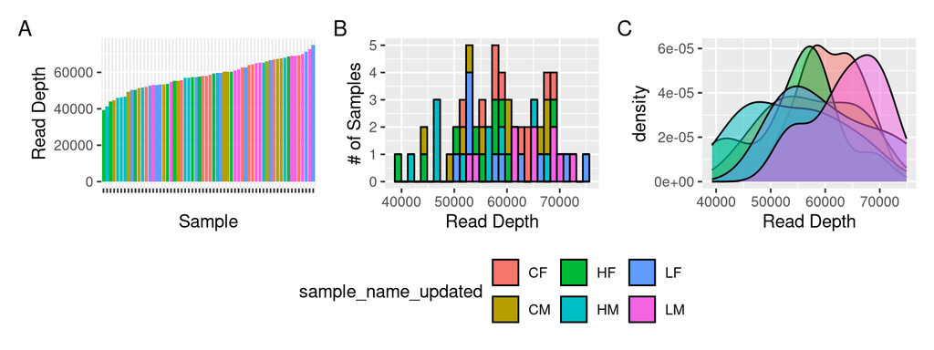

```r
# plot it as a bar plot
numSeq_bar_plot <-
  seqSums_df %>%
  ggplot(aes(x=reorder(names, TotalSeqs), y = TotalSeqs,
             fill = sample_name_updated)) +
  geom_bar(stat = "identity") +
  theme(axis.text.x = element_blank()) +
  labs(y = "Read Depth", x = "Sample") +
  theme(legend.position = "none")

# histogram
numSeq_hist_plot <-
  seqSums_df %>%
  ggplot(aes(x= TotalSeqs, fill =  sample_name_updated)) +
  geom_histogram(color = "black") +
  labs(y = "# of Samples", x = "Read Depth") +
  theme(legend.position = "bottom")

# Density plot
numSeq_density_plot <-
  seqSums_df %>%
  ggplot(aes(TotalSeqs, fill =  sample_name_updated)) +
  geom_density(alpha = 0.5) +
  labs(x = "Read Depth") +
  theme(legend.position = "none")

# Put it all together
numSeq_bar_plot + numSeq_hist_plot + numSeq_density_plot +
  plot_annotation(tag_levels = "A")
```

NTERPRETATION #5: What can you conclude about your sequencing depths?

Looking at the bar plot, histogram, and density plot, I think all of the samples have sufficient read depth, and are relatively even compared to one another.

What are your sample distributions?

Do you have “enough” reads? I think all samples have enough reads. Looking at the bar plot, the lowest read depth from a sample is slightly under 40,000, but the read depths of samples increase evenly, which indicates to me that all of them are real and unalarming. I would be alarmed if there were samples with no reads, or samples with a disproportionately higher read depth than others, but that is not the case with this data.

Are there any samples that should be removed at this step?

The only reads that worry me are the two lowest-read-depth samples in the histogram. There are two samples that have a read depth of around 40,000 and 42,000 respectively. However, these samples belong to the “high temperature male” and “high temperature female” samples. The paper noted that higher temperatures lowered the microbial diversity in snail guts, so this may be in line with what the researchers observed too.

### Remove samples with few reads

Check the minimum sequence depth: since there are no outlier samples with significantly less reads, no samples will be removed.

```r
# What's the min seq depth?
min(sample_sums(noChlorosMitosNegPosControls_physeq))
```

```
## [1] 39242
```

```r
# Minimum seq depth is 39,242, so I won't be removing any samples
raw_preprocessed_physeq <- noChlorosMitosNegPosControls_physeq
```

## Save raw_preprocessed_physeq

```r
save(raw_preprocessed_physeq, file = "data/03_PreProcessing/raw_preprocessed_physeq.RData")
```

# Final info for Reproducibility

## Check Render Time

```r
# Take the time now that we are at the end of the script
end_time <- Sys.time()
end_time
```

```
## [1] "2025-05-02 01:51:18 EDT"
```

```r
# Echo the elapsed time
elapsed_time <- round((end_time - start_time), 3)
elapsed_time
```

```
## Time difference of 40.55 secs
```